# Demographics analysis 2 - HB and COVID

COVID Admissions - January 2020 to Febraury 2022

HB - 9-digit code for health board of treatment based on boundaries as at 1st April 2019

- Age Groups and total count for each
  - Under 5 1348
  - 5 - 14 1331
  - 15 - 44 1581
  - 45 - 64 1637
    - 65 - 74 1611
  - 75 - 84 1637
  - 85 and over 1549
  - (remember to filter out - needed for sex analysis - All ages 5039)
- Sex total count
  - All 12374 (remember to filter out - need for age analysis)
  - Female 1680
  - Male 1679
- SIMD total count
  - 1 1344 “Most Deprived”
  - 2 1533
  - 3 1651
  - 4 1568
  - 5 1342

```r
library(tidyverse)
library(here)
library(janitor)
```

```r
library(ggplot2)
library(stringr)
```

Read In Data

```r
covid_admissions_HB_agesex <- read_csv(here("../../clean_data/covid_hosp_admissions_hb_agesex_clean.csv"))
covid_admissions_HB_simd <- read_csv(here("../../clean_data/covid_hosp_admissions_hb_simd_clean.csv"))
```

#### What are we working with?

**health board values are S08000015 - s08000032** **https://www.opendata.nhs.scot/dataset/geography-codes-and-labels/resource/944765d7-d0d9-46a0-b377-abb3de51d08e**

```r
covid_admissions_HB_agesex %>%
  group_by(age_group) %>%
  count()
```

| age_group | n |
| --- | --- |
| 15 - 44 | 1581 |
| 45 - 64 | 1637 |
| 5 - 14 | 1331 |
| 65 - 74 | 1611 |
| 75 - 84 | 1637 |
| 85 and over | 1549 |
| All ages | 5039 |
| Under 5 | 1348 |

```r
covid_admissions_HB_agesex %>%
  group_by(sex) %>%
  count()
```

| sex | n |
| --- | --- |
| All | 12374 |
| Female | 1680 |
| Male | 1679 |

```r
covid_admissions_HB_simd %>%
  group_by(simd_quintile) %>%
  count()
```

| simd_quintile | n |
| --- | --- |
| 1 | 1344 |
| 2 | 1533 |
| 3 | 1651 |
| 4 | 1568 |
| 5 | 1342 |

### HB - Age - Total Covid admissions

April 2020 will be shown first and ages are a mess. So:

```r
dates <- c("January 2020", "February 2020", "March 2020", "April 2020",
           "May 2020", "June 2020", "July 2020", "August 2020",
           "September 2020", "October 2020", "November 2020", "December 2020",
           "January 2021", "February 2021", "March 2021", "April 2021",
           "May 2021", "June 2021", "July 2021", "August 2021",
           "September 2021", "October 2021", "November 2021", "December 2021",
           "January 2022", "February 2022")

quarter_dates <- c("2016Q3", "2016Q4", "2017Q1", "2017Q2", "2017Q3", "2017Q4",
                   "2018Q1", "2018Q2", "2018Q3", "2018Q4", "2019Q1", "2019Q2",
                   "2019Q3", "2019Q4", "2020Q1", "2020Q2", "2020Q3", "2020Q4",
                   "2021Q1", "2021Q2", "2021Q3")

q1 <- c("January 2020", "February 2020", "March 2020", "January 2021",
        "February 2021", "March 2021", "January 2022", "February 2022")

q2 <- c("April 2020", "May 2020", "June 2020", "April 2021", "May 2021",
        "June 2021")

q3 <- c("July 2020", "August 2020", "September 2020", "July 2021",
        "August 2021", "September 2021")

q4 <- c("October 2020", "November 2020", "December 2020", "October 2021",
        "November 2021", "December 2021")
```

**PLOT OF Total COVID admissions per month by age group**

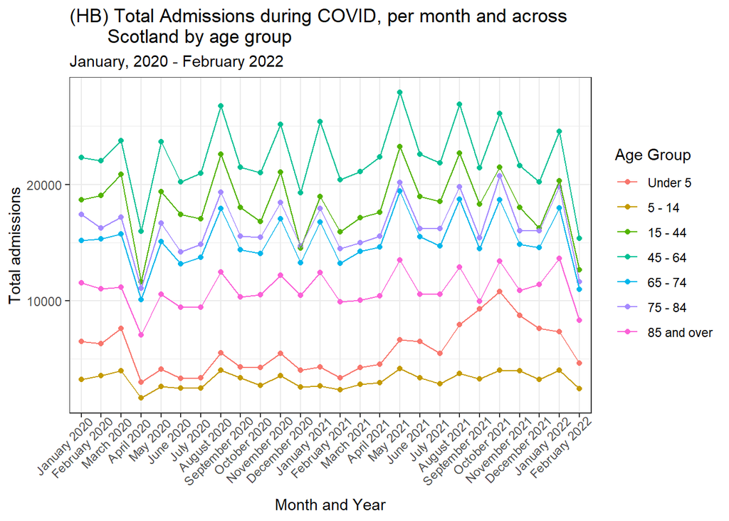

```r
covid_admissions_HB_agesex %>%
  filter(age_group != "All ages") %>%
  mutate(age_group = fct_relevel(age_group,
                                 "Under 5", "5 - 14", "15 - 44",
                                 "45 - 64", "65 - 74", "75 - 84",
                                 "85 and over")) %>%
  ggplot()+
  aes(x = wk_ending_yr_month,
      y = total_admissions_per_month_age,
      group = age_group,
      colour = age_group)+
  scale_x_discrete(limits = dates) +
  geom_point()+
  geom_line()+
  labs(x = "Month and Year",
       y = "Total admissions",
       title = "(HB) Total Admissions during COVID, per month and across
       Scotland by age group",
       subtitle = "January, 2020 - February 2022",
       colour = "Age Group") +
  theme_bw()+
  theme(axis.text.x = element_text(angle = 45, hjust = 0.9))
```

By Quarter:

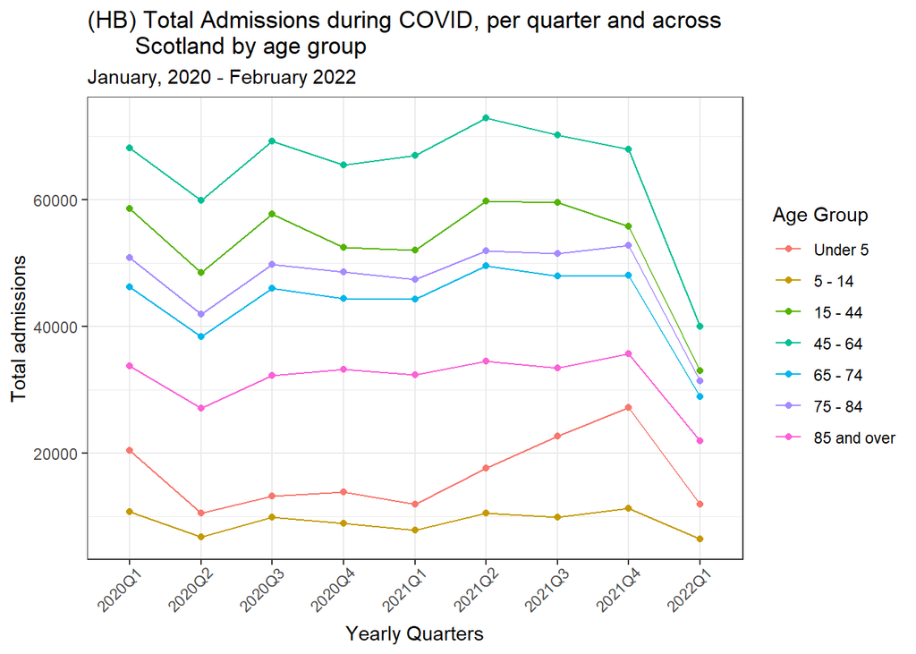

```r
covid_admissions_HB_agesex %>%
  filter(age_group != "All ages") %>%
  mutate(age_group = fct_relevel(age_group,
                                 "Under 5", "5 - 14", "15 - 44",
                                 "45 - 64", "65 - 74", "75 - 84",
                                 "85 and over")) %>%
  ggplot()+
  aes(x = year_quarter,
      y = total_admissions_per_quarter_age,
      group = age_group,
      colour = age_group)+
  geom_point()+
  geom_line()+
  labs(x = "Yearly Quarters",
       y = "Total admissions",
       title = "(HB) Total Admissions during COVID, per quarter and across
       Scotland by age group",
       subtitle = "January, 2020 - February 2022",
       colour = "Age Group") +
  theme_bw()+
  theme(axis.text.x = element_text(angle = 45, hjust = 0.9))
```

### HB -Age- Weekly COVID admissions against the average admissions in 2018 & 19

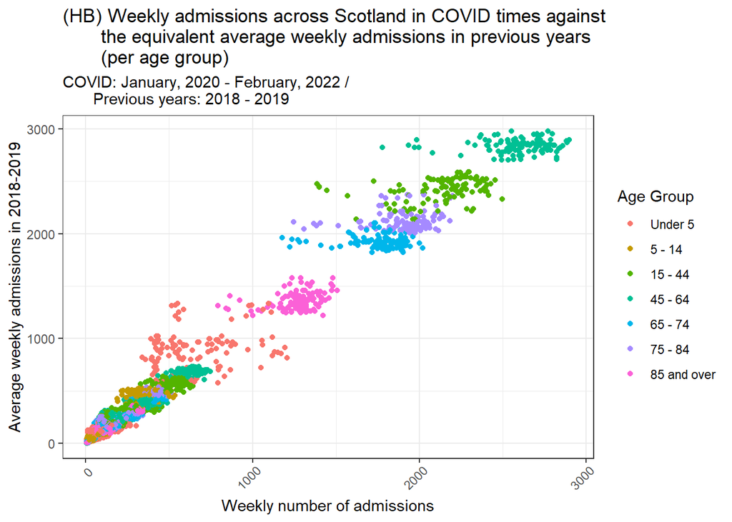

```r
covid_admissions_HB_agesex %>%
  filter(age_group != "All ages") %>%
  mutate(age_group = fct_relevel(age_group,
                                 "Under 5", "5 - 14", "15 - 44",
                                 "45 - 64", "65 - 74", "75 - 84",
                                 "85 and over")) %>%
  group_by(age_group) %>%
  ggplot()+
  aes(x = number_admissions,
      y = average20182019,
      colour = age_group)+
  geom_point() +
  labs(x = "Weekly number of admissions",
       y = "Average weekly admissions in 2018-2019",
       title = "(HB) Weekly admissions across Scotland in COVID times against
       the equivalent average weekly admissions in previous years
       (per age group)",
       subtitle = "COVID: January, 2020 - February, 2022 /
       Previous years: 2018 - 2019",
       colour = "Age Group") +
  theme_bw()+
  theme(axis.text.x = element_text(angle = 45, hjust = 0.9))
```

**The above but by month instead of EVERY input**

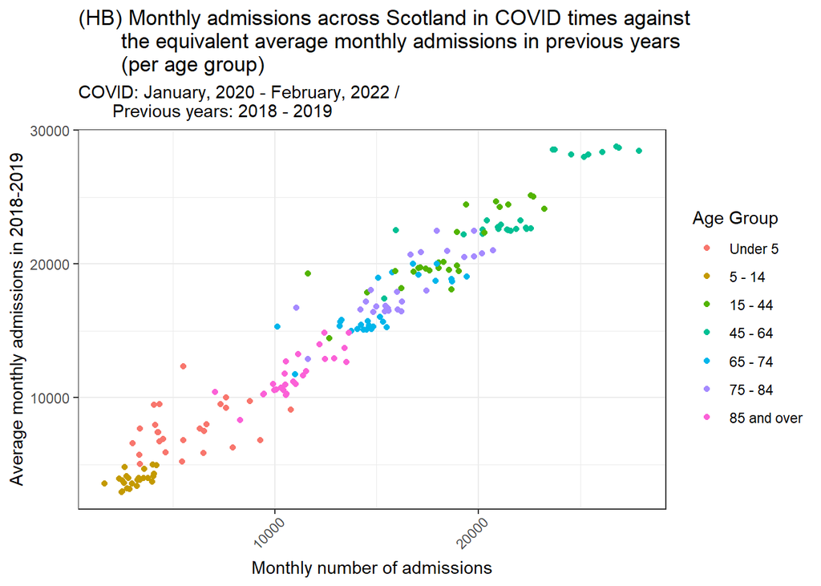

```r
covid_admissions_HB_agesex %>%
  filter(age_group != "All ages") %>%
  mutate(age_group = fct_relevel(age_group,
                                 "Under 5", "5 - 14", "15 - 44",
                                 "45 - 64", "65 - 74", "75 - 84",
                                 "85 and over")) %>%
  group_by(age_group) %>%
  ggplot()+
  aes(x = total_admissions_per_month_age,
      y = admissions_2018_19_per_month_age,
      colour = age_group)+
  geom_point() +
  labs(x = "Monthly number of admissions",
       y = "Average monthly admissions in 2018-2019",
       title = "(HB) Monthly admissions across Scotland in COVID times against
       the equivalent average monthly admissions in previous years
       (per age group)",
       subtitle = "COVID: January, 2020 - February, 2022 /
       Previous years: 2018 - 2019",
       colour = "Age Group") +
  theme_bw()+
  theme(axis.text.x = element_text(angle = 45, hjust = 0.9))
```

Total admissions across HBs by gender for week ending:

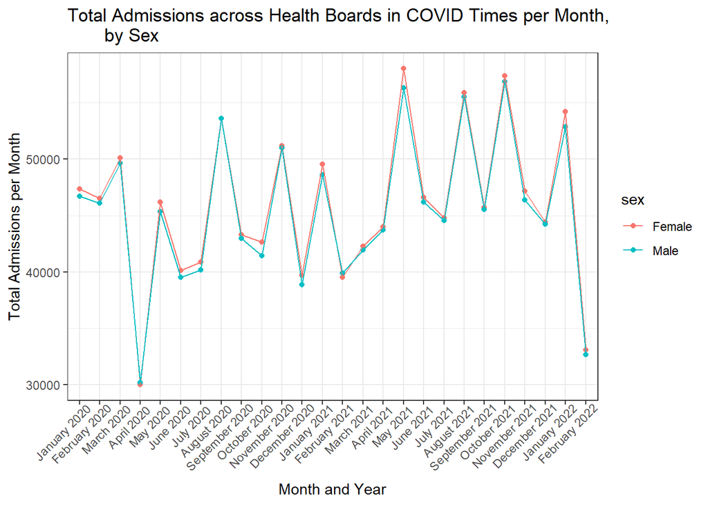

```r
covid_admissions_HB_agesex %>%
  filter(sex != "All") %>%
  ggplot()+
  aes(x = wk_ending_yr_month,
      y = total_admissions_per_month_sex,
      group = sex,
      colour = sex)+
  scale_x_discrete(limits = dates) +
  geom_point()+
  geom_line()+
  labs(x = "Month and Year",
       y = "Total Admissions per Month",
       title = "Total Admissions across Health Boards in COVID Times per Month,
       by Sex",
       fill = "Sex")+
  theme_bw()+
  theme(axis.text.x = element_text(angle = 45, hjust = 0.9))
```

Trying again but with a bar chart - Total admissions across HBs by gender for week ending

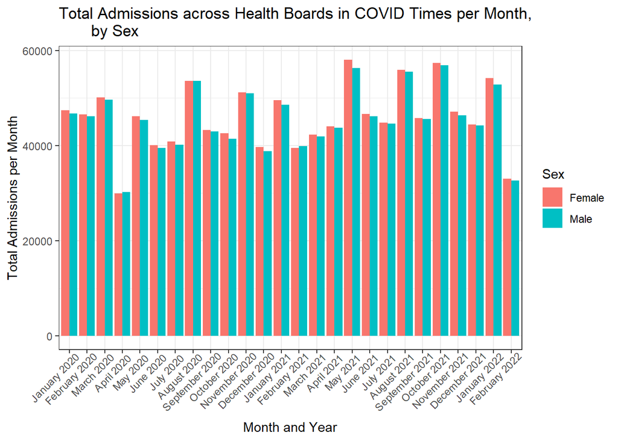

```r
covid_admissions_HB_agesex %>%
  filter(sex != "All") %>%
  ggplot()+
  aes(x = wk_ending_yr_month,
      y = total_admissions_per_month_sex,
      fill = sex)+
  scale_x_discrete(limits = dates) +
  geom_col(position = "dodge")+
  labs(x = "Month and Year",
       y = "Total Admissions per Month",
       title = "Total Admissions across Health Boards in COVID Times per Month,
       by Sex",
       fill = "Sex")+
  theme_bw()+
  theme(axis.text.x = element_text(angle = 45, hjust = 0.9))
```

Sex - total admissions By quarter

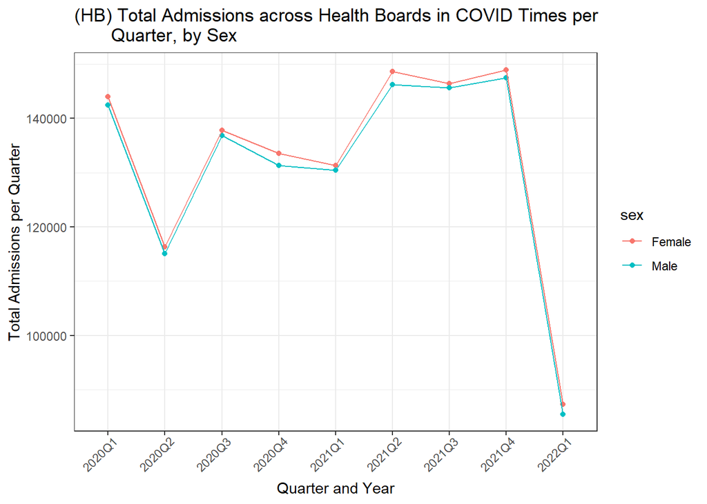

```r
covid_admissions_HB_agesex %>%
  filter(sex != "All") %>%
  ggplot()+
  aes(x = year_quarter,
      y = total_admissions_per_quarter_sex,
      group = sex,
      colour = sex)+
  geom_point()+
  geom_line()+
  labs(x = "Quarter and Year",
       y = "Total Admissions per Quarter",
       title = "(HB) Total Admissions across Health Boards in COVID Times per
       Quarter, by Sex",
       fill = "Sex")+
  theme_bw()+
  theme(axis.text.x = element_text(angle = 45, hjust = 0.9))
```

## HEALTH BOARD - SIMD

### HB - SIMD - Total Admissions

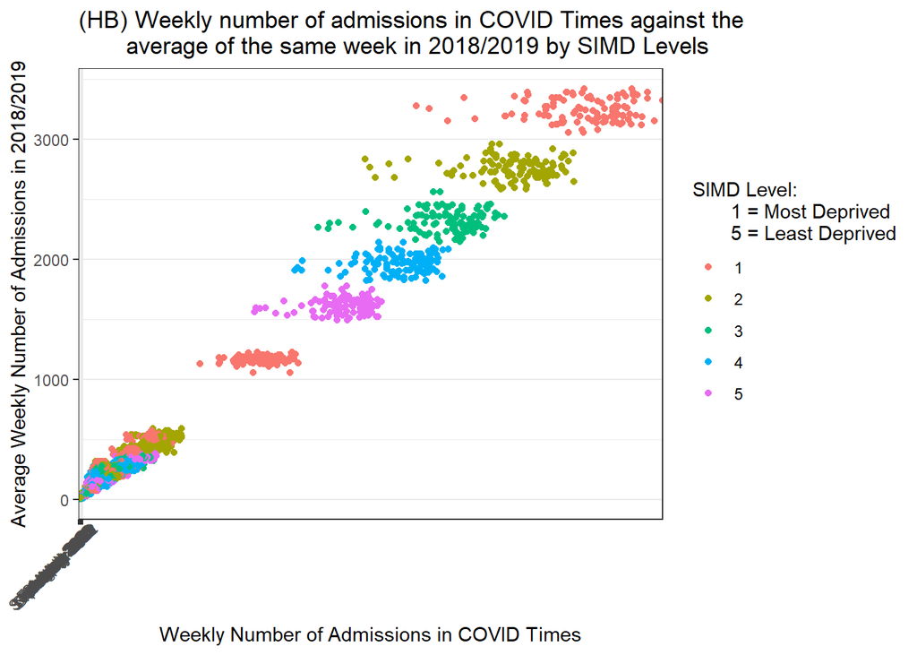

```r
covid_admissions_HB_simd %>%
  mutate(simd_quintile = fct_relevel(as.character(simd_quintile,
                                  "1", "2", "3", "4", "5"))) %>%
  group_by(wk_ending_yr_month, simd_quintile) %>%
  ggplot()+
  aes(x = number_admissions,
      y = average20182019,
      colour = simd_quintile)+
  scale_x_discrete(limits = dates) +
  geom_point()+
  labs(x = "Weekly Number of Admissions in COVID Times",
       y = "Average Weekly Number of Admissions in 2018/2019",
       title = "(HB) Weekly number of admissions in COVID Times against the
       average of the same week in 2018/2019 by SIMD Levels",
      colour = "SIMD Level:
       1 = Most Deprived
       5 = Least Deprived")+
  theme_bw()+
  theme(axis.text.x = element_text(angle = 45, hjust = 0.9))
```

**PLOT total admissions per simd per month**

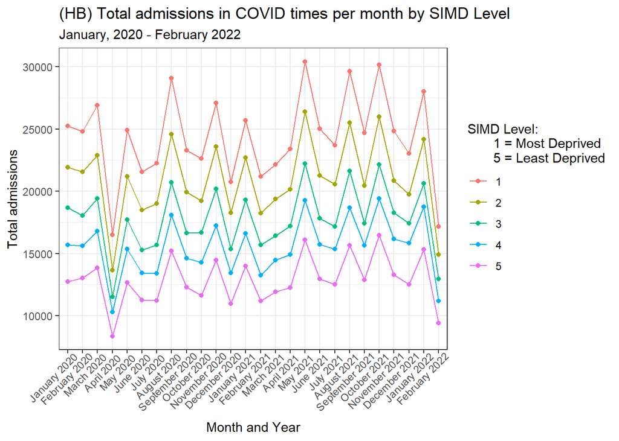

```r
covid_admissions_HB_simd %>%
  mutate(simd_quintile = fct_relevel(as.character(simd_quintile,
                                  "1", "2", "3", "4", "5"))) %>%
  group_by(wk_ending_yr_month, simd_quintile) %>%
  ggplot()+
  aes(x = wk_ending_yr_month,
      y = total_admissions_per_month_simd,
      group = simd_quintile,
      colour = simd_quintile)+
  scale_x_discrete(limits = dates) +
  geom_point()+
  geom_line()+
  labs(x = "Month and Year",
       y = "Total admissions",
       title = "(HB) Total admissions in COVID times per month by SIMD Level",
       subtitle = "January, 2020 - February 2022",
       colour = "SIMD Level:
       1 = Most Deprived
       5 = Least Deprived") +
  theme_bw()+
  theme(axis.text.x = element_text(angle = 45, hjust = 0.9))
```

SIMD - monthly AVERAGE admissions 2018 and 2019 against COVID admissions

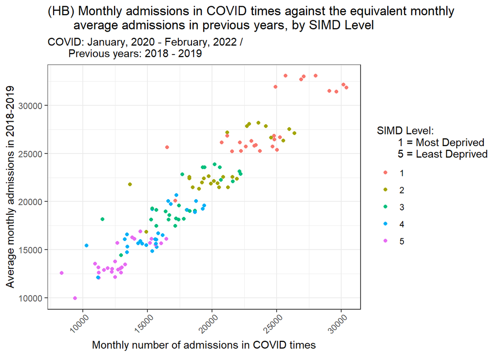

```r
covid_admissions_HB_simd %>%
   mutate(simd_quintile = fct_relevel(as.character(simd_quintile,
                                  "1", "2", "3", "4", "5"))) %>%
  group_by(simd_quintile) %>%
  ggplot()+
  aes(x = total_admissions_per_month_simd,
      y = admissions_2018_19_per_month_simd,
      colour = simd_quintile)+
  geom_point()+
  labs(x = "Monthly number of admissions in COVID times",
       y = "Average monthly admissions in 2018-2019",
       title = "(HB) Monthly admissions in COVID times against the equivalent monthly
       average admissions in previous years, by SIMD Level",
       subtitle = "COVID: January, 2020 - February, 2022 /
       Previous years: 2018 - 2019",
       colour = "SIMD Level:
       1 = Most Deprived
       5 = Least Deprived") +
  theme_bw()+
  theme(axis.text.x = element_text(angle = 45, hjust = 0.9))
```

SIMD total admissions BY QUARTER

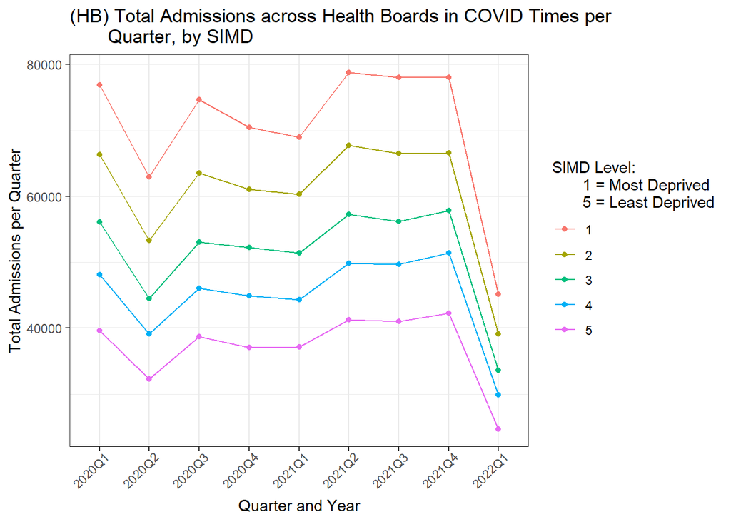

```r
covid_admissions_HB_simd %>%
  mutate(simd_quintile = fct_relevel(as.character(simd_quintile,
                                  "1", "2", "3", "4", "5"))) %>%
  ggplot()+
  aes(x = year_quarter,
      y = total_admissions_per_quarter_simd,
      group = simd_quintile,
      colour = simd_quintile)+
  geom_point()+
  geom_line()+
  labs(x = "Quarter and Year",
       y = "Total Admissions per Quarter",
       title = "(HB) Total Admissions across Health Boards in COVID Times per
       Quarter, by SIMD",
       colour = "SIMD Level:
       1 = Most Deprived
       5 = Least Deprived")+
  theme_bw()+
  theme(axis.text.x = element_text(angle = 45, hjust = 0.9))
```

SIMD - quarterly AVERAGE admissions 2018 and 2019 against COVID admissions

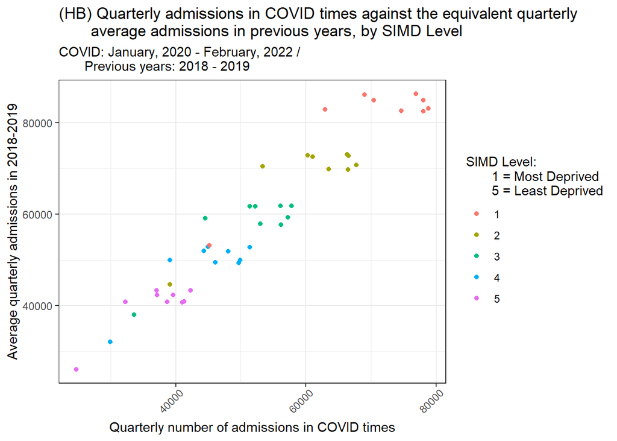

```r
covid_admissions_HB_simd %>%
   mutate(simd_quintile = fct_relevel(as.character(simd_quintile,
                                  "1", "2", "3", "4", "5"))) %>%
  group_by(simd_quintile) %>%
  ggplot()+
  aes(x = total_admissions_per_quarter_simd,
      y = admissions_2018_19_per_quarter_simd,
      colour = simd_quintile)+
  geom_point()+
  labs(x = "Quarterly number of admissions in COVID times",
       y = "Average quarterly admissions in 2018-2019",
       title = "(HB) Quarterly admissions in COVID times against the equivalent quarterly
       average admissions in previous years, by SIMD Level",
       subtitle = "COVID: January, 2020 - February, 2022 /
       Previous years: 2018 - 2019",
       colour = "SIMD Level:
       1 = Most Deprived
       5 = Least Deprived") +
  theme_bw()+
  theme(axis.text.x = element_text(angle = 45, hjust = 0.9))
```

### SIMD by health board

*NOTE - I think the top line s92000003 is “Scotland”* so took it out (Most deprived (1)): *2nd is Greater Glasgow and clyde* 3rd is Lanarkshire * 4th ayrshire and arran * 5th Lothian

```r
# covid_admissions_HB_simd %>%
#   distinct(hb)
covid_admissions_HB_simd_healthboards <- covid_admissions_HB_simd %>%
  filter(hb != "S92000003") %>%
  group_by(hb, simd_quintile, wk_ending_yr_month) %>%
  mutate(total_admissions_per_month_healthboard_simd = sum(number_admissions))
```

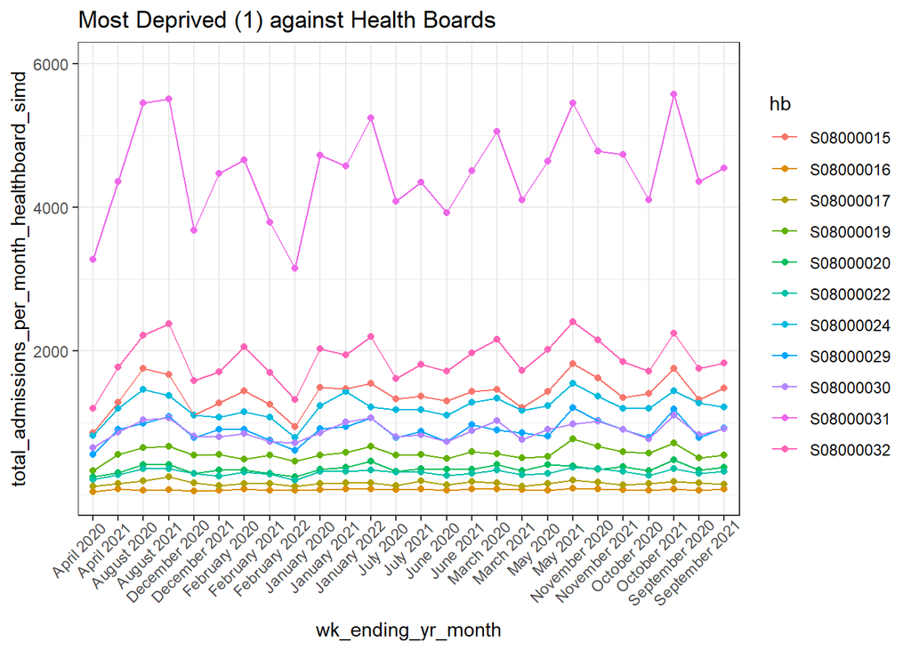

```r
covid_admissions_HB_simd_healthboards %>%
  filter(simd_quintile == "1") %>%
  group_by(wk_ending_yr_month) %>%
  ggplot()+
  aes(x = wk_ending_yr_month,
      y = total_admissions_per_month_healthboard_simd,
      group = hb,
      colour = hb)+
  geom_point()+
  geom_line()+
  labs(title = "Most Deprived (1) against Health Boards")+
  scale_y_continuous(breaks = c(2000, 4000, 6000),
                     limits = c(0, 6000))+
  theme_bw()+
  theme(axis.text.x = element_text(angle = 45, hjust = 0.9))
```

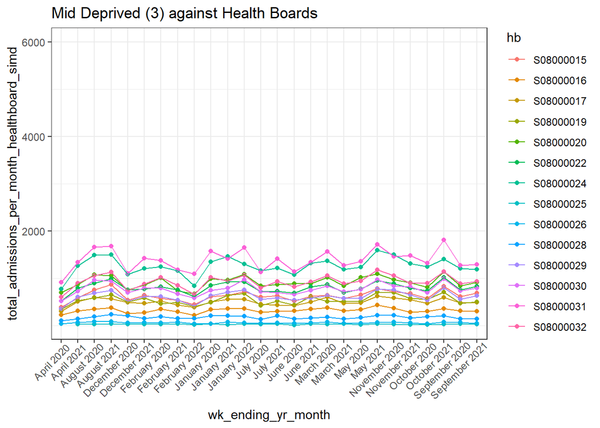

```r
covid_admissions_HB_simd_healthboards %>%
  filter(simd_quintile == "3") %>%
  group_by(wk_ending_yr_month) %>%
  ggplot()+
  aes(x = wk_ending_yr_month,
      y = total_admissions_per_month_healthboard_simd,
      group = hb,
      colour = hb)+
  geom_point()+
  geom_line()+
  labs(title = "Mid Deprived (3) against Health Boards")+
  scale_y_continuous(breaks = c(2000, 4000, 6000),
                     limits = c(0, 6000))+
  theme_bw()+
  theme(axis.text.x = element_text(angle = 45, hjust = 0.9))
```

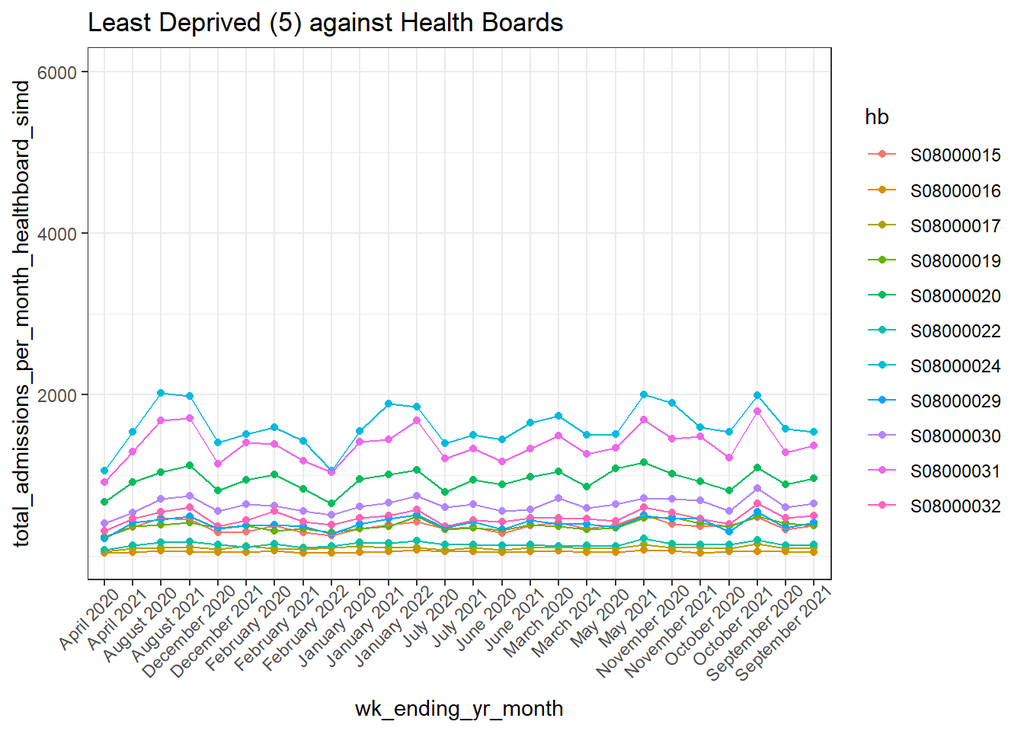

```r
covid_admissions_HB_simd_healthboards %>%
  filter(simd_quintile == "5") %>%
  group_by(wk_ending_yr_month) %>%
  ggplot()+
  aes(x = wk_ending_yr_month,
      y = total_admissions_per_month_healthboard_simd,
      group = hb,
      colour = hb)+
  geom_point()+
  geom_line()+
  labs(title = "Least Deprived (5) against Health Boards")+
  scale_y_continuous(breaks = c(2000, 4000, 6000),
                     limits = c(0, 6000))+
  theme_bw()+
  theme(axis.text.x = element_text(angle = 45, hjust = 0.9))
```

# STATISTICS SIMD COVID TIMES

- Looking at COVID times - emergency admissions - by SIMD

I need the mean of total admissions for each simd quintile:

```r
covid_admissions_HB_simd %>%
  group_by(simd_quintile) %>%
  summarise(mean_total_admissions = mean(total_admissions_per_month_simd))
```

| simd_quintile | mean_total_admissions |
| --- | --- |
| 1 | 24739.57 |
| 2 | 21268.93 |
| 3 | 18042.26 |
| 4 | 15741.16 |
| 5 | 13039.47 |

## SIMD 1 (most deprived) and SIMD 3 (mid deprivation)

$$H0 : μ_{SIMD\ 1:\ (most\ deprived)} -
μ_{SIMD\ 3\ (mid\ deprived)} = 0$$
$$Ha : μ_{SIMD\ 1:\ (most\ deprived)} - μ_{SIMD\ 3\
(mid\ deprived)} > 0$$

```r
library(infer)
```

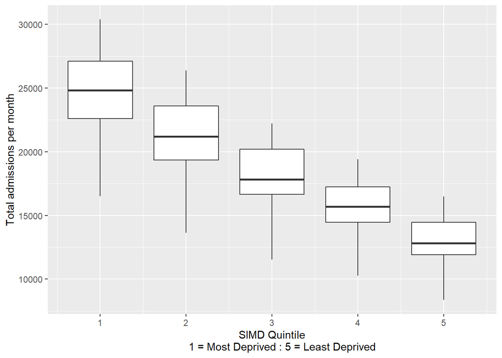

```r
covid_admissions_HB_simd %>%
  ggplot(aes(x = simd_quintile,
             y = total_admissions_per_month_simd,
             group = simd_quintile))+
  geom_boxplot() +
  labs(x = "SIMD Quintile
       1 = Most Deprived : 5 = Least Deprived",
       y = "Total admissions per month")
```

permutation to generate the null distribution NOTE - we only want 1 and 3 just now

```r
covid_admissions_HB_simd_one_three <- covid_admissions_HB_simd %>%
  filter(simd_quintile == "1" | simd_quintile == "3") %>%
  mutate(simd_quintile = as.character(simd_quintile))

null_distribution_most_mid <- covid_admissions_HB_simd_one_three %>%
  specify(total_admissions_per_month_simd~simd_quintile) %>%
  hypothesise(null = "independence") %>%
  generate(reps = 1000, type = "permute") %>%
  calculate(stat = "diff in means", order = c("1", "3"))
head(null_distribution_most_mid)
```

| replicate | stat |
| --- | --- |
| 1 | 168.817702 |
| 2 | -6.359801 |
| 3 | -222.476303 |
| 4 | 96.009966 |
| 5 | 57.549092 |
| 6 | 207.449993 |

observed stat:

```r
observed_stat_one_three <- covid_admissions_HB_simd_one_three %>%
  specify(total_admissions_per_month_simd~simd_quintile) %>%
  calculate(stat = "diff in means", order = c("1", "3"))
observed_stat_one_three
```

| stat |
| --- |
| 6697.316 |

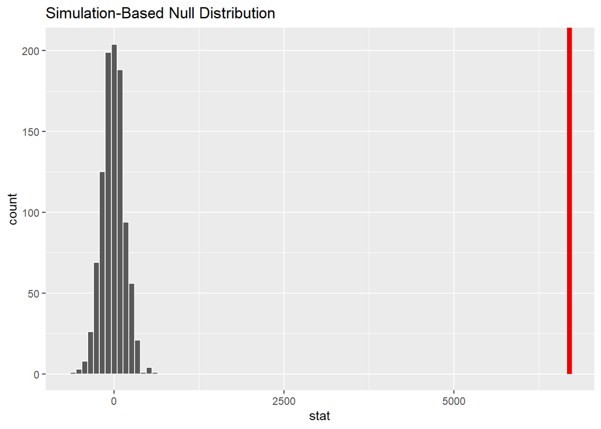

```r
null_distribution_most_mid %>%
  visualise()+
  shade_p_value(obs_stat = observed_stat_one_three, direction = "right")
```

```r
p_value <- null_distribution_most_mid %>%
  get_p_value(obs_stat = observed_stat_one_three, direction = "right")
p_value
```

| p_value |
| --- |
| 0 |

```r
format.pval(p_value)
```

```
## [1] "< 2.22e-16"
```

# BETWEEN 3 and 5 (least deprived)

$$H0 : μ_{SIMD\ 3:\ (mid\ deprived)} -
μ_{SIMD\ 5\ (least\ deprived)} = 0$$
$$Ha : μ_{SIMD\ 3:\ (mid\ deprived)} - μ_{SIMD\ 5\
(least\ deprived)} > 0$$

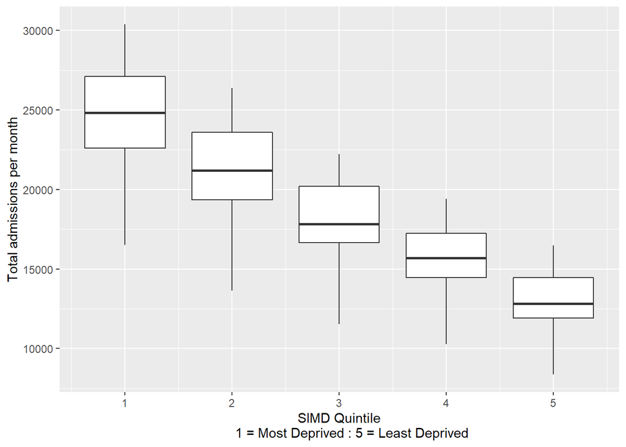

```r
covid_admissions_HB_simd %>%
  ggplot(aes(x = simd_quintile, y = total_admissions_per_month_simd, group = simd_quintile))+
  geom_boxplot() +
  labs(x = "SIMD Quintile
       1 = Most Deprived : 5 = Least Deprived",
       y = "Total admissions per month")
```

permutation to generate the null distribution NOTE - we only want 3 and 5 just now

```r
covid_admissions_HB_simd_three_five <- covid_admissions_HB_simd %>%
  filter(simd_quintile == "3" | simd_quintile == "5") %>%
  mutate(simd_quintile = as.character(simd_quintile))

null_distribution_mid_least <- covid_admissions_HB_simd_three_five %>%
  specify(total_admissions_per_month_simd ~ simd_quintile) %>%
  hypothesise(null = "independence") %>%
  generate(reps = 1000, type = "permute") %>%
  calculate(stat = "diff in means", order = c("3", "5"))
head(null_distribution_mid_least)
```

| replicate | stat |
| --- | --- |
| 1 | -36.90303 |
| 2 | -71.71039 |
| 3 | -110.31633 |
| 4 | -19.33253 |
| 5 | 124.56677 |
| 6 | 35.78485 |

observed stat:

```r
observed_stat_mid_least <- covid_admissions_HB_simd_three_five %>%
  specify(total_admissions_per_month_simd ~ simd_quintile) %>%
  calculate(stat = "diff in means", order = c("3", "5"))
observed_stat_mid_least
```

| stat |
| --- |
| 5002.785 |

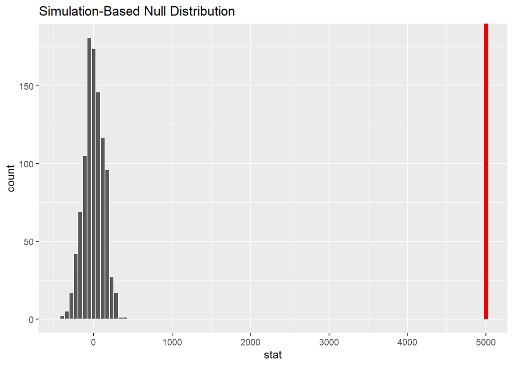

```r
null_distribution_mid_least %>%
  visualise()+
  shade_p_value(obs_stat = observed_stat_mid_least, direction = "right")
```

```r
p_value_mid_least <- null_distribution_mid_least %>%
  get_p_value(obs_stat = observed_stat_mid_least, direction = "right")
p_value_mid_least
```

| p_value |
| --- |
| 0 |

```r
format.pval(p_value_mid_least)
```

```
## [1] "< 2.22e-16"
```

Total monthly admissions in COVID times for SIMD - measures of spread

```r
covid_admissions_HB_simd %>%
  group_by(simd_quintile) %>%
  summarise(
    Mean = mean(total_admissions_per_month_simd),
    Q1 = quantile(total_admissions_per_month_simd, 0.25),
    Q2 = quantile(total_admissions_per_month_simd, 0.5),
    Q3 = quantile(total_admissions_per_month_simd, 0.75),
    IQR = Q3 - Q1
  )
```

| simd_quintile | Mean | Q1 | Q2 | Q3 | IQR |
| --- | --- | --- | --- | --- | --- |
| 1 | 24739.57 | 22616 | 24826.0 | 27101 | 4485 |
| 2 | 21268.93 | 19365 | 21183.0 | 23587 | 4222 |
| 3 | 18042.26 | 16646 | 17826.0 | 20198 | 3552 |
| 4 | 15741.16 | 14455 | 15678.5 | 17251 | 2796 |
| 5 | 13039.47 | 11914 | 12816.5 | 14465 | 2551 |